# Proceso de descarga e instalción de R y RStudio

Author

Gerardo Esteban, Gómez-Santiago

Published

October 11, 2024

Para poder realizar el [Taller Introductorio al Análisis Estadístico en R](https://sites.google.com/view/taller-r-gomezesteban/inicio) es necesario tener instalado dos programas.

- Software R
- Software RStudio

Para la descarga de los mismos debes acceder al siguiente link https://posit.co/download/rstudio-desktop/, donde encontraras los siguientes botones de descarga.

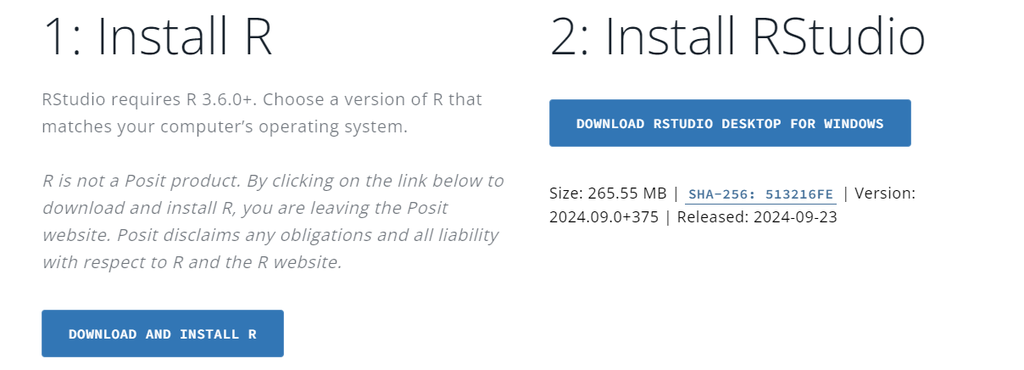

## R

### Descarga

Empezando por R, una vez apretas el botón de descarga te redirige a la siguiente pagina, en la cual debes seleccionar la opción de descarga que te corresponda según tu sistema operativo.

[figure not shown]

En caso de que tu sistema operativo sea Windows, te encontraras con la siguiente pagina, en la cual debes elegir la opción **base** que esta señalada por el recuadro rojo. Si tu sistema operativo es macOS no puedo ayudarte con el paso a paso, pero la verdad es muy intuitivo y te recomiendo este video donde muestran como hacerlo [video](https://www.youtube.com/watch?v=OW66f1sBQOc)

[figure not shown]

Al seleccionar esa opción, te aparecera la ultima versión disponible de R (la cual esta señalada en rojo abajo), dale click y ya se inicia el proceso de descarga.

[figure not shown]

### Instalación

Una vez descargado, seguramente aparecera como archivo ejecutable (.exe) en tu carpeta de descargas, abrelo y sigue las configuraciones por defecto (dale siempre siguiente) y por ultimo finalizar.

[figure not shown]

[figure not shown]

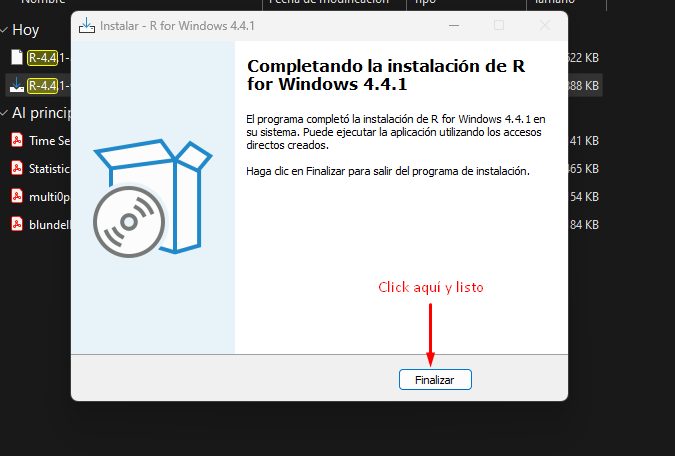

Si seguiste las configuraciones por defecto, en tu escritorio deberias tener un acceso directo a R como el que aparece en la siguiente imagen.

[figure not shown]

Si no te sale no te preocupes, ve a Configuración > Aplicaciones > Aplicaciones instaladas y revisa que este R como en la siguiente imagen.

[figure not shown]

## RStudio

RStudio es el programa que diariamente vas a abrir para hacer tus análisis estadísticos, gráficar o generar informes, por definición es un ambiente de trabajo, el cual es mucho más amigable y comodo para programar en R. Lo que quiero decir con esto, es que es posible programar en R sin utilizar RStudio, pero atravesar esa curva de aprendizaje es mucho mas difícil.

### Descarga

Una vez aprietas el botón de descarga de RStudio en el link de posit (https://posit.co/download/rstudio-desktop/), este inicia la descarga automáticamente.

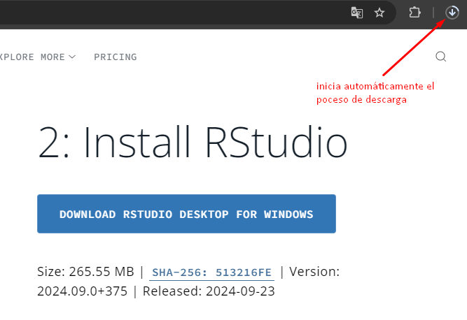

### Instalación

De nuevo te encontraras con un archivo ejecutable en tu carpeta de descargas, uno como el de la imagen de abajo, abrelo, dale permiso para modificar cosas en tu computadora y sigue las configuraciones predeterminadas.

[figure not shown]

[figure not shown]

[figure not shown]

[figure not shown]

Una vez finalizada la instalación, al abrir RStudio te va a preguntar que versión de R usar (imagen de abajo), hay una opción de autodetección que ya viene preestablecida, asi que solo dale ok y ya estaría listo para ser usado.

[figure not shown]

Si tienes problemas con la instalación comunicate conmigo a tráves de WhatsApp (+57 313 335 2017) o correo eléctronico (gomezsantiagogerardoesteban@gmail.com), la idea es que lo hagas antes de nuestro primer encuentro, bien sea lunes 14 o miércoles 16 de octubre, de esa manera ya podemos empezar la clase trabajando en el ambiente y dando nuestros primeros pasos en código.